# FORDGOBIKE TripData

## by Abdallah Saoud

## Intro

**A marketing CEO at a bike company is looking to lanch a new service ...but did not know when to launch , where to lanch and what adjustments could be made to fit the largest group of your customers.**

In order to know when to launch we will need to see which day is the **busiest day**

and where to launch we will need to know the **busiest station**

### The most common age

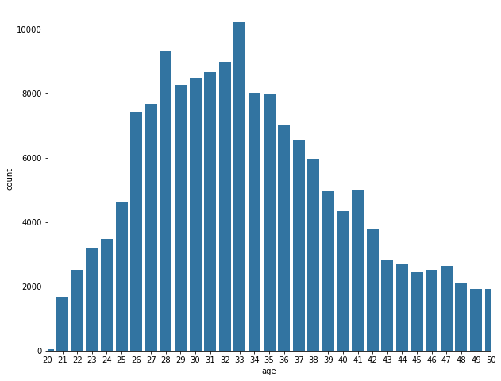

### checking the busiest day

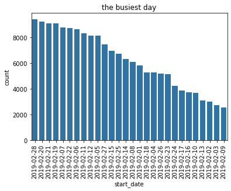

As we can see 28/02/2019 which is thursday is the busiest day

### checking the busiest Station

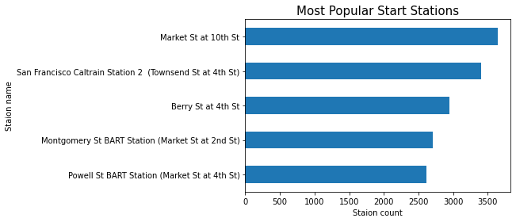

#### Does gender affect trip duration ?

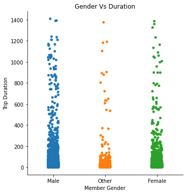

**Male users show more usage as you can see the first coulmn is more dense from the bottom up than the others.**

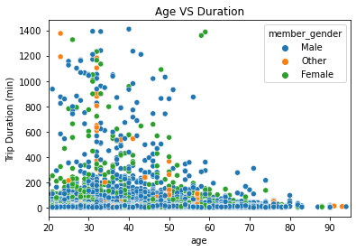

**Checking the busiest day of the week and by which gender**

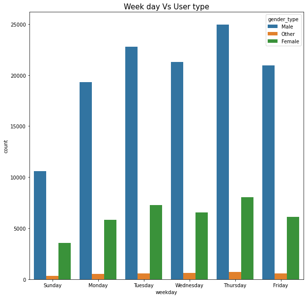